# Aula Interativa - XP Educação

```r
"std", "std", "std", "turbo", "std", "std", "std", "std",
"std", "std", "std", "std", "std", "std", "std", "std", "std",
"turbo", "std", "std", "std", "turbo", "std", "turbo", "std",
"std", "std", "std", "std", "std", "std", "std", "std", "std",
"std", "std", "std", "std", "std", "std", "std", "std", "std",
"std", "std", "std", "std", "std", "std", "std", "std", "std",
"std", "std", "std", "std", "std", "std", "std", "turbo",
"turbo", "turbo", "turbo", "std", "std", "std", "std", "turbo",
"std", "std", "std", "turbo", "turbo", "std", "turbo", "turbo",
"turbo", "std", "std", "turbo", "std", "std", "std", "std",
"std", "std", "std", "std", "std", "std", "std", "std", "std",
"std", "std", "std", "std", "turbo", "std", "std", "turbo",
"std", "turbo", "std", "turbo", "std", "turbo", "std", "turbo",
"turbo", "std", "turbo", "std", "std", "std", "std", "turbo",
"std", "std", "std", "std", "std", "std", "std", "std", "std",
"std", "turbo", "turbo", "std", "std", "std", "std", "std",
"std", "std", "turbo", "std", "std", "std", "turbo", "std",
"std", "std", "std", "std", "std", "std", "std", "std", "std",
"std", "std", "std", "std", "std", "std", "std", "std", "std",
"std", "std", "std", "std", "std", "turbo", "std", "std",
"std", "std", "std", "std", "std", "std", "std", "std", "std",
"std", "turbo", "std", "std", "std", "std", "turbo", "std",
"std", "std", "std", "std", "turbo", "turbo", "std", "turbo",
"std", "turbo", "turbo"), `num-of-doors` = c("two", "two",
"two", "four", "four", "two", "four", "four", "four", "two",
"four", "two", "four", "four", "four", "two", "four", "two",
"two", "four", "two", "two", "two", "four", "four", "four",
"?", "four", "two", "two", "two", "two", "two", "two", "four",
"four", "two", "two", "four", "four", "four", "two", "four",
"two", "four", "four", "two", "two", "two", "two", "four",
"four", "two", "two", "two", "two", "two", "four", "two",
"four", "?", "four", "four", "four", "four", "four", "two",
"four", "four", "two", "four", "two", "two", "two", "two",
"two", "two", "two", "two", "two", "two", "two", "four",
"four", "four", "four", "two", "two", "two", "four", "four",
"two", "two", "four", "four", "two", "four", "four", "four",
"four", "four", "two", "two", "two", "four", "four", "four",
"four", "four", "four", "four", "four", "four", "four", "four",
"two", "two", "four", "four", "four", "four", "two", "two",
"two", "two", "two", "four", "two", "two", "four", "two",
"four", "two", "four", "two", "two", "two", "four", "four",
"four", "four", "four", "four", "four", "four", "four", "two",
"two", "four", "four", "four", "four", "four", "four", "four",
"four", "four", "four", "four", "two", "two", "two", "two",
"two", "two", "two", "two", "two", "two", "four", "four",
"four", "four", "four", "two", "two", "four", "four", "two",
"two", "four", "four", "four", "four", "four", "two", "two",
"four", "four", "four", "four", "four", "four", "four", "four",
"four", "four", "four", "four", "four", "four"), `body-style` = c("convertible",
"convertible", "hatchback", "sedan", "sedan", "sedan", "sedan",
"wagon", "sedan", "sedan", "sedan", "sedan", "sedan", "sedan",
"sedan", "sedan", "sedan", "hatchback", "hatchback", "sedan",
"hatchback", "hatchback", "hatchback", "hatchback", "sedan",
"sedan", "sedan", "wagon", "hatchback", "hatchback", "hatchback",
"hatchback", "hatchback", "hatchback", "sedan", "wagon",
"hatchback", "hatchback", "sedan", "sedan", "sedan", "sedan",
"sedan", "hatchback", "sedan", "sedan", "sedan", "hatchback",
"hatchback", "hatchback", "sedan", "sedan", "hatchback",
"hatchback", "hatchback", "hatchback", "hatchback", "sedan",
"hatchback", "sedan", "sedan", "hatchback", "sedan", "sedan",
"sedan", "wagon", "hardtop", "sedan", "sedan", "convertible",
"sedan", "hardtop", "hatchback", "hatchback", "hatchback",
"hatchback", "hatchback", "hatchback", "hatchback", "hatchback",
"hatchback", "hatchback", "sedan", "sedan", "sedan", "sedan",
"sedan", "sedan", "sedan", "sedan", "wagon", "sedan", "hatchback",
"sedan", "wagon", "hardtop", "hatchback", "sedan", "sedan",
"wagon", "sedan", "hatchback", "hatchback", "hatchback",
"sedan", "sedan", "wagon", "wagon", "sedan", "sedan", "wagon",
"wagon", "sedan", "sedan", "sedan", "hatchback", "hatchback",
"hatchback", "sedan", "sedan", "wagon", "hatchback", "hatchback",
"hardtop", "hardtop", "convertible", "wagon", "hatchback",
"hatchback", "sedan", "hatchback", "sedan", "hatchback",
"sedan", "hatchback", "hatchback", "hatchback", "sedan",
"sedan", "sedan", "sedan", "sedan", "wagon", "wagon", "wagon",
"wagon", "hatchback", "hatchback", "hatchback", "wagon",
"wagon", "wagon", "sedan", "hatchback", "sedan", "hatchback",
"sedan", "hatchback", "sedan", "sedan", "hatchback", "sedan",
"hatchback", "hardtop", "hardtop", "hatchback", "hardtop",
"hatchback", "convertible", "sedan", "sedan", "hatchback",
"sedan", "hatchback", "hatchback", "hatchback", "sedan",
"wagon", "sedan", "sedan", "sedan", "sedan", "sedan", "sedan",
"sedan", "convertible", "hatchback", "sedan", "sedan", "wagon",
"sedan", "wagon", "sedan", "wagon", "sedan", "wagon", "sedan",
"sedan", "sedan", "sedan", "sedan"), `drive-wheels` = c("rwd",
"rwd", "rwd", "fwd", "4wd", "fwd", "fwd", "fwd", "fwd", "rwd",
"rwd", "rwd", "rwd", "rwd", "rwd", "rwd", "rwd", "fwd", "fwd",
"fwd", "fwd", "fwd", "fwd", "fwd", "fwd", "fwd", "fwd", "fwd",
"fwd", "fwd", "fwd", "fwd", "fwd", "fwd", "fwd", "fwd", "fwd",
"fwd", "fwd", "fwd", "fwd", "fwd", "rwd", "rwd", "rwd", "rwd",
"rwd", "fwd", "fwd", "fwd", "fwd", "fwd", "rwd", "rwd", "rwd",
"rwd", "fwd", "fwd", "fwd", "fwd", "fwd", "fwd", "rwd", "rwd",
"rwd", "rwd", "rwd", "rwd", "rwd", "rwd", "rwd", "rwd", "rwd",
"fwd", "fwd", "fwd", "fwd", "fwd", "fwd", "fwd", "fwd", "fwd",
"fwd", "fwd", "fwd", "fwd", "fwd", "fwd", "fwd", "fwd", "fwd",
"fwd", "fwd", "fwd", "fwd", "fwd", "fwd", "fwd", "fwd", "fwd",
"fwd", "rwd", "rwd", "rwd", "rwd", "rwd", "rwd", "rwd", "rwd",
"rwd", "rwd", "rwd", "rwd", "rwd", "rwd", "fwd", "fwd", "fwd",
"fwd", "fwd", "fwd", "rwd", "rwd", "rwd", "rwd", "rwd", "fwd",
"fwd", "fwd", "fwd", "fwd", "fwd", "fwd", "fwd", "fwd", "fwd",
"4wd", "fwd", "fwd", "fwd", "4wd", "4wd", "fwd", "fwd", "4wd",
"4wd", "fwd", "fwd", "fwd", "fwd", "4wd", "4wd", "fwd", "fwd",
"fwd", "fwd", "fwd", "fwd", "fwd", "rwd", "rwd", "rwd", "rwd",
"rwd", "rwd", "rwd", "rwd", "rwd", "rwd", "fwd", "fwd", "fwd",
"fwd", "fwd", "rwd", "rwd", "rwd", "rwd", "fwd", "fwd", "fwd",
"fwd", "fwd", "fwd", "fwd", "fwd", "fwd", "fwd", "fwd", "fwd",
"rwd", "rwd", "rwd", "rwd", "rwd", "rwd", "rwd", "rwd", "rwd",
"rwd", "rwd"), `engine-location` = c("front", "front", "front",
"front", "front", "front", "front", "front", "front", "front",
"front", "front", "front", "front", "front", "front", "front",
"front", "front", "front", "front", "front", "front", "front",
"front", "front", "front", "front", "front", "front", "front",
"front", "front", "front", "front", "front", "front", "front",
"front", "front", "front", "front", "front", "front", "front",
"front", "front", "front", "front", "front", "front", "front",
"front", "front", "front", "front", "front", "front", "front",
"front", "front", "front", "front", "front", "front", "front",
"front", "front", "front", "front", "front", "front", "front",
"front", "front", "front", "front", "front", "front", "front",
"front", "front", "front", "front", "front", "front", "front",
"front", "front", "front", "front", "front", "front", "front",
"front", "front", "front", "front", "front", "front", "front",
"front", "front", "front", "front", "front", "front", "front",
"front", "front", "front", "front", "front", "front", "front",
"front", "front", "front", "front", "front", "front", "front",
"front", "rear", "rear", "rear", "front", "front", "front",
"front", "front", "front", "front", "front", "front", "front",
"front", "front", "front", "front", "front", "front", "front",
"front", "front", "front", "front", "front", "front", "front",
"front", "front", "front", "front", "front", "front", "front",
"front", "front", "front", "front", "front", "front", "front",
"front", "front", "front", "front", "front", "front", "front",
"front", "front", "front", "front", "front", "front", "front",
"front", "front", "front", "front", "front", "front", "front",
"front", "front", "front", "front", "front", "front", "front",
"front", "front", "front", "front", "front", "front", "front",
"front", "front"), `num-of-cylinders` = c("four", "four",
          "six", "four", "five", "five", "five", "five", "five", "four",
          "four", "six", "six", "six", "six", "six", "six", "three",
          "four", "four", "four", "four", "four", "four", "four", "four",
          "four", "four", "four", "four", "four", "four", "four", "four",
          "four", "four", "four", "four", "four", "four", "four", "four",
          "four", "four", "six", "six", "twelve", "four", "four", "four",
          "four", "four", "two", "two", "two", "two", "four", "four",
          "four", "four", "four", "four", "four", "four", "five", "five",
          "five", "five", "eight", "eight", "eight", "eight", "four",
          "four", "four", "four", "four", "four", "four", "four", "four",
          "four", "four", "four", "four", "four", "four", "four", "four",
          "four", "four", "four", "four", "four", "four", "four", "four",
          "four", "six", "six", "six", "six", "six", "six", "four",
          "four", "four", "four", "four", "four", "four", "four", "four",
          "four", "four", "four", "four", "four", "four", "four", "four",
          "four", "four", "six", "six", "six", "four", "four", "four",
          "four", "four", "four", "four", "four", "four", "four", "four",
          "four", "four", "four", "four", "four", "four", "four", "four",
          "four", "four", "four", "four", "four", "four", "four", "four",
          "four", "four", "four", "four", "four", "four", "four", "four",
          "four", "four", "four", "four", "four", "four", "four", "four",
          "four", "four", "four", "four", "four", "six", "six", "six",
          "six", "four", "four", "four", "four", "four", "four", "four",
          "four", "four", "five", "four", "four", "four", "four", "four",
          "four", "four", "four", "four", "four", "six", "six", "four"))
```

```r
#Renomeia as colunas para portugues
names(dados) <- c('Preco',
                  'Comprimento',
                  'Largura',
                  'Altura',
                  'Peso',
                  'Tamanho_Motor',
                  'Milhas_por_Litro_na_Cidade',
                  'Milhas_por_Litro_na_Estrada',
                  'Tipo_Combustivel',
                  'Possui_Turbo',
                  'Numero_de_Portas',
                  'Estilo_do_Corpo',
                  'Tracao',
                  'Localizacao_do_Motor',
                  'Numero_de_Cilindros')
```

# Preparação dos dados

Visualiza o tipo de cada variavel

```r
str(dados)
```

```
## 'data.frame':    201 obs. of  15 variables:
##  $ Preco                      : num  13495 16500 16500 13950 17450 ...
##  $ Comprimento                : num  169 169 171 177 177 ...
##  $ Largura                    : num  64.1 64.1 65.5 66.2 66.4 66.3 71.4 71.4 71.4 64.8 ...
##  $ Altura                     : num  48.8 48.8 52.4 54.3 54.3 53.1 55.7 55.7 55.9 54.3 ...
##  $ Peso                       : num  2548 2548 2823 2337 2824 ...
##  $ Tamanho_Motor              : num  130 130 152 109 136 136 136 136 131 108 ...
##  $ Milhas_por_Litro_na_Cidade : num  21 21 19 24 18 19 19 19 17 23 ...
##  $ Milhas_por_Litro_na_Estrada: num  27 27 26 30 22 25 25 25 20 29 ...
##  $ Tipo_Combustivel           : chr  "gas" "gas" "gas" "gas" ...
##  $ Possui_Turbo               : chr  "std" "std" "std" "std" ...
##  $ Numero_de_Portas           : chr  "two" "two" "two" "four" ...
##  $ Estilo_do_Corpo            : chr  "convertible" "convertible" "hatchback" "sedan" ...
##  $ Tracao                     : chr  "rwd" "rwd" "rwd" "fwd" ...
##  $ Localizacao_do_Motor       : chr  "front" "front" "front" "front" ...
##  $ Numero_de_Cilindros        : chr  "four" "four" "six" "four" ...
```

Converte as variaveis categoricas para factor

```r
dados$Tipo_Combustivel <- as.factor(dados$Tipo_Combustivel)
dados$Possui_Turbo <- as.factor(dados$Possui_Turbo)
dados$Numero_de_Portas <- as.factor(dados$Numero_de_Portas)
dados$Estilo_do_Corpo <- as.factor(dados$Estilo_do_Corpo)
dados$Tracao <- as.factor(dados$Tracao)
dados$Localizacao_do_Motor <- as.factor(dados$Localizacao_do_Motor)
dados$Numero_de_Cilindros <- as.factor(dados$Numero_de_Cilindros)
```

Com a biblioteca dplyr, e possivel converter todas variaveis categoricas

```r
dados <- dados %>% mutate_if(is.character,as.factor)

str(dados)
```

```
## 'data.frame':    201 obs. of  15 variables:
##  $ Preco                      : num  13495 16500 16500 13950 17450 ...
##  $ Comprimento                : num  169 169 171 177 177 ...
##  $ Largura                    : num  64.1 64.1 65.5 66.2 66.4 66.3 71.4 71.4 71.4 64.8 ...
##  $ Altura                     : num  48.8 48.8 52.4 54.3 54.3 53.1 55.7 55.7 55.9 54.3 ...
##  $ Peso                       : num  2548 2548 2823 2337 2824 ...
##  $ Tamanho_Motor              : num  130 130 152 109 136 136 136 136 131 108 ...
##  $ Milhas_por_Litro_na_Cidade : num  21 21 19 24 18 19 19 19 17 23 ...
##  $ Milhas_por_Litro_na_Estrada: num  27 27 26 30 22 25 25 25 20 29 ...
##  $ Tipo_Combustivel           : Factor w/ 2 levels "diesel","gas": 2 2 2 2 2 2 2 2 2 2 ...
##  $ Possui_Turbo               : Factor w/ 2 levels "std","turbo": 1 1 1 1 1 1 1 1 2 1 ...
##  $ Numero_de_Portas           : Factor w/ 3 levels "?","four","two": 3 3 3 2 2 3 2 2 2 3 ...
##  $ Estilo_do_Corpo            : Factor w/ 5 levels "convertible",..: 1 1 3 4 4 4 4 5 4 4 ...
##  $ Tracao                     : Factor w/ 3 levels "4wd","fwd","rwd": 3 3 3 2 1 2 2 2 2 3 ...
##  $ Localizacao_do_Motor       : Factor w/ 2 levels "front","rear": 1 1 1 1 1 1 1 1 1 1 ...
##  $ Numero_de_Cilindros        : Factor w/ 7 levels "eight","five",..: 3 3 4 3 2 2 2 2 2 3 ...
```

Visualiza resumo descritivo das variaveis

```r
summary(dados)
```

```
##      Preco        Comprimento       Largura          Altura           Peso
##  Min.   : 5118   Min.   :141.1   Min.   :60.30   Min.   :47.80   Min.   :1488
##  1st Qu.: 7775   1st Qu.:166.8   1st Qu.:64.10   1st Qu.:52.00   1st Qu.:2169
##  Median :10295   Median :173.2   Median :65.50   Median :54.10   Median :2414
##  Mean   :13207   Mean   :174.2   Mean   :65.89   Mean   :53.77   Mean   :2556
##  3rd Qu.:16500   3rd Qu.:183.5   3rd Qu.:66.60   3rd Qu.:55.50   3rd Qu.:2926
##  Max.   :45400   Max.   :208.1   Max.   :72.00   Max.   :59.80   Max.   :4066
##
##  Tamanho_Motor   Milhas_por_Litro_na_Cidade Milhas_por_Litro_na_Estrada
##  Min.   : 61.0   Min.   :13.00              Min.   :16.00
##  1st Qu.: 98.0   1st Qu.:19.00              1st Qu.:25.00
##  Median :120.0   Median :24.00              Median :30.00
##  Mean   :126.9   Mean   :25.18              Mean   :30.69
##  3rd Qu.:141.0   3rd Qu.:30.00              3rd Qu.:34.00
##  Max.   :326.0   Max.   :49.00              Max.   :54.00
##
##  Tipo_Combustivel Possui_Turbo Numero_de_Portas    Estilo_do_Corpo Tracao
##  diesel: 20       std  :165    ?   :  2         convertible: 6     4wd:  8
##  gas   :181       turbo: 36    four:113         hardtop    : 8     fwd:118
##                                two : 86         hatchback  :68     rwd: 75
##                                                 sedan      :94
##                                                 wagon      :25
##
##
##  Localizacao_do_Motor Numero_de_Cilindros
##  front:198            eight :  4
##  rear :  3            five  : 10
##                       four  :157
##                       six   : 24
##                       three :  1
##                       twelve:  1
##                       two   :  4
```

#Analise exploratória dos dados

Explora a variavel resposta: Preco

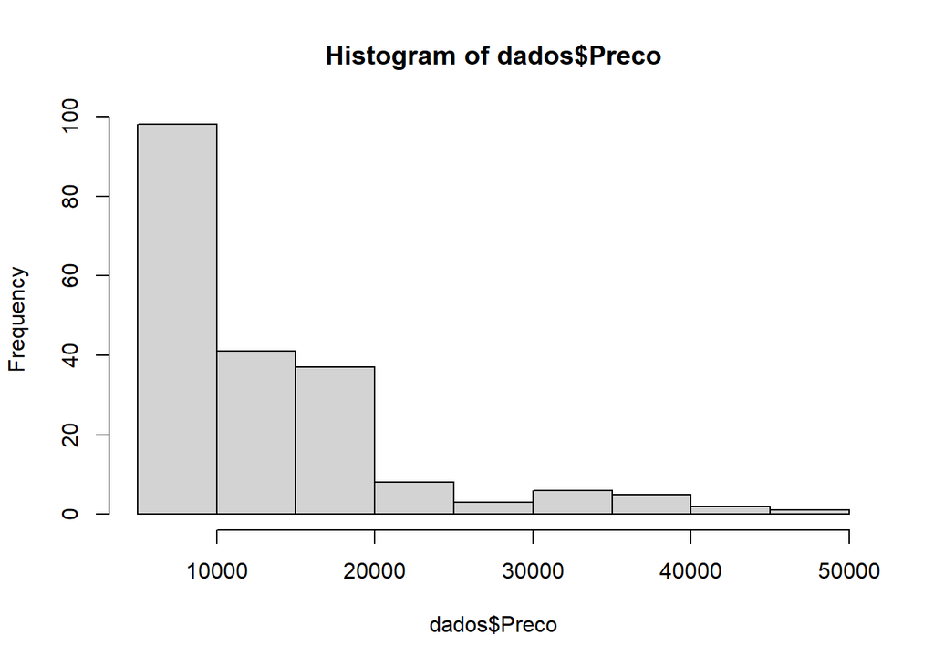

```r
hist(dados$Preco)
```

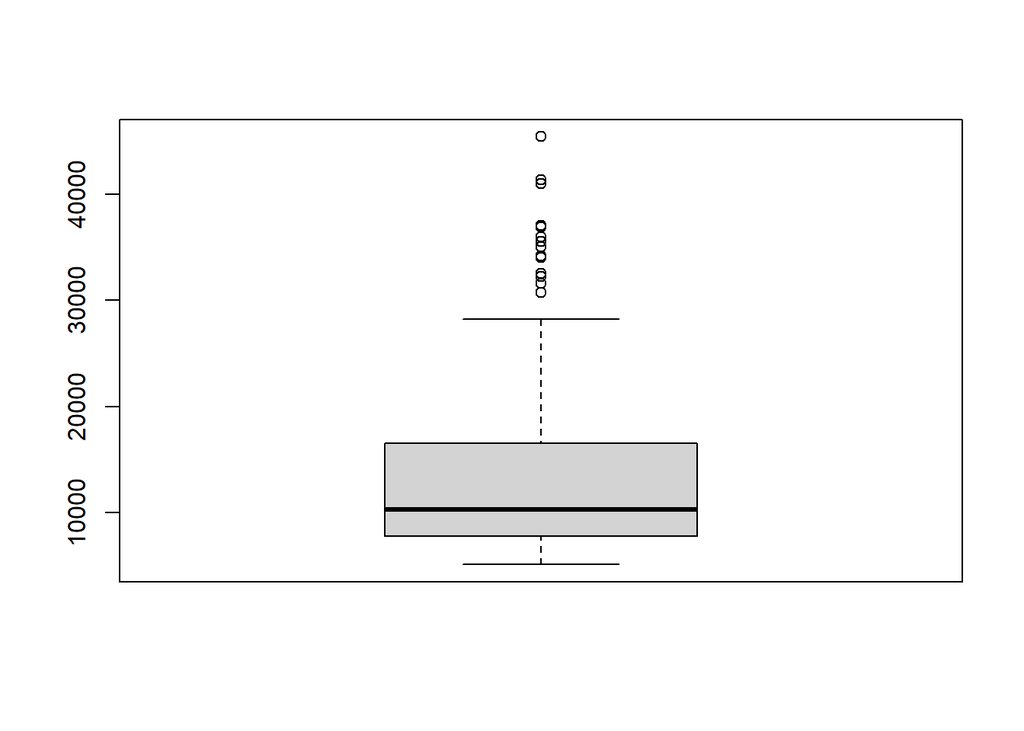

```r
boxplot(dados$Preco)
```

```r
summary(dados$Preco)
```

```
##    Min. 1st Qu.  Median    Mean 3rd Qu.    Max.
##    5118    7775   10295   13207   16500   45400
```

Suspeita-se que a variavel Tipo_Combustivel possui associacao com o fato do veiculo Possuir_Turbo. Investigue a relação entre essas variáveis

```r
tabela_contigencia <- table(dados$Tipo_Combustivel, dados$Possui_Turbo)
tabela_contigencia
```

```
##
##          std turbo
##   diesel   7    13
##   gas    158    23
```

```r
chisq.test(tabela_contigencia)
```

```
##
##  Pearson's Chi-squared test with Yates' continuity correction
##
## data:  tabela_contigencia
## X-squared = 30.034, df = 1, p-value = 4.244e-08
```

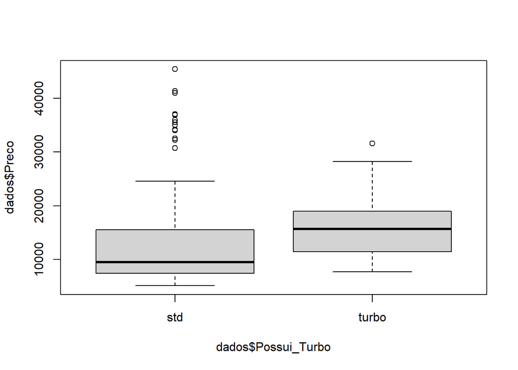

```r
boxplot(dados$Preco ~ dados$Possui_Turbo)
```

```r
t.test(dados$Preco ~ dados$Possui_Turbo)
```

```
##
##  Welch Two Sample t-test
##
## data:  dados$Preco by dados$Possui_Turbo
## t = -3.0693, df = 64.602, p-value = 0.003135
## alternative hypothesis: true difference in means between group std and group turbo is not equal to 0
## 95 percent confidence interval:
##  -6128.623 -1296.625
## sample estimates:
##   mean in group std mean in group turbo
##            12542.18            16254.81
```

Explore a relação entre as variáveis Preço e Peso

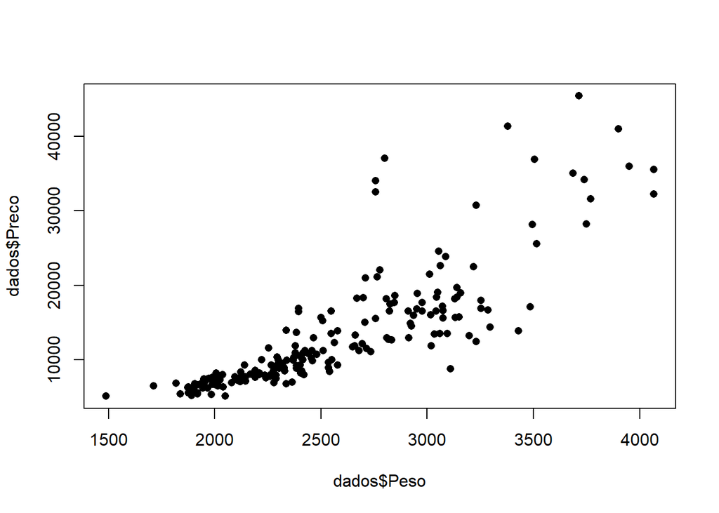

```r
plot(y = dados$Preco,
     x = dados$Peso,
     pch = 16)
```

Coeficiente de correlacao entre Preco e Peso

```r
cor(dados$Preco, dados$Peso)
```

```
## [1] 0.8344145
```

# Análise de Regressão Linear

Regressao linear simples entre Peso e Preco

```r
fit <- lm(Preco ~ Peso, data = dados)
summary(fit)
```

```
##
## Call:
## lm(formula = Preco ~ Peso, data = dados)
##
## Residuals:
##      Min       1Q   Median       3Q      Max
## -11535.0  -2037.3   -317.9   1379.2  20688.8
##
## Coefficients:
##               Estimate Std. Error t value Pr(>|t|)
## (Intercept) -1.955e+04  1.565e+03  -12.49   <2e-16 ***
## Peso         1.282e+01  6.002e-01   21.36   <2e-16 ***
## ---
## Signif. codes:  0 '***' 0.001 '**' 0.01 '*' 0.05 '.' 0.1 ' ' 1
##
## Residual standard error: 4391 on 199 degrees of freedom
## Multiple R-squared:  0.6962, Adjusted R-squared:  0.6947
## F-statistic: 456.1 on 1 and 199 DF,  p-value: < 2.2e-16
```

Regressao linear multipla

```r
fit <- lm(Preco ~ ., data = dados)
summary(fit)
```

```
##
## Call:
## lm(formula = Preco ~ ., data = dados)
##
## Residuals:
##     Min      1Q  Median      3Q     Max
## -6544.2 -1388.6   -30.3  1258.8 15327.4
##
## Coefficients:
##                               Estimate Std. Error t value Pr(>|t|)
## (Intercept)                 -4.888e+04  1.576e+04  -3.102 0.002237 **
## Comprimento                 -2.019e-01  5.261e+01  -0.004 0.996942
## Largura                      6.183e+02  2.572e+02   2.404 0.017241 *
## Altura                       2.499e+02  1.290e+02   1.938 0.054211 .
## Peso                         1.823e+00  1.926e+00   0.947 0.345068
## Tamanho_Motor                7.774e+01  1.858e+01   4.185 4.50e-05 ***
## Milhas_por_Litro_na_Cidade  -2.371e+02  1.592e+02  -1.490 0.138132
## Milhas_por_Litro_na_Estrada  2.632e+02  1.523e+02   1.728 0.085716 .
## Tipo_Combustivelgas          1.328e+03  1.160e+03   1.144 0.253998
## Possui_Turboturbo            1.801e+03  7.356e+02   2.448 0.015337 *
## Numero_de_Portasfour         1.223e+01  2.000e+03   0.006 0.995127
## Numero_de_Portastwo          6.284e+02  2.071e+03   0.304 0.761867
## Estilo_do_Corpohardtop      -3.841e+03  1.590e+03  -2.416 0.016731 *
## Estilo_do_Corpohatchback    -3.197e+03  1.344e+03  -2.378 0.018465 *
## Estilo_do_Corposedan        -1.840e+03  1.474e+03  -1.248 0.213779
## Estilo_do_Corpowagon        -3.570e+03  1.619e+03  -2.205 0.028774 *
## Tracaofwd                   -7.448e+02  1.160e+03  -0.642 0.521754
## Tracaorwd                    1.388e+03  1.202e+03   1.155 0.249773
## Localizacao_do_Motorrear     1.330e+04  2.042e+03   6.513 7.46e-10 ***
## Numero_de_Cilindrosfive     -5.009e+03  2.316e+03  -2.162 0.031949 *
## Numero_de_Cilindrosfour     -9.067e+03  2.402e+03  -3.775 0.000219 ***
## Numero_de_Cilindrossix      -6.408e+03  2.043e+03  -3.137 0.002001 **
## Numero_de_Cilindrosthree    -4.794e+03  4.015e+03  -1.194 0.234046
## Numero_de_Cilindrostwelve   -6.121e+03  3.398e+03  -1.801 0.073356 .
## Numero_de_Cilindrostwo      -3.346e+03  3.496e+03  -0.957 0.339891
## ---
## Signif. codes:  0 '***' 0.001 '**' 0.01 '*' 0.05 '.' 0.1 ' ' 1
##
## Residual standard error: 2726 on 176 degrees of freedom
## Multiple R-squared:  0.8965, Adjusted R-squared:  0.8824
## F-statistic: 63.51 on 24 and 176 DF,  p-value: < 2.2e-16
```

```r
fit <- lm(Preco ~ ., data = dados)
summary(fit)
```

```
##
## Call:
## lm(formula = Preco ~ ., data = dados)
##
## Residuals:
##     Min      1Q  Median      3Q     Max
## -6544.2 -1388.6   -30.3  1258.8 15327.4
##
## Coefficients:
##                               Estimate Std. Error t value Pr(>|t|)
## (Intercept)                 -4.888e+04  1.576e+04  -3.102 0.002237 **
## Comprimento                 -2.019e-01  5.261e+01  -0.004 0.996942
## Largura                      6.183e+02  2.572e+02   2.404 0.017241 *
## Altura                       2.499e+02  1.290e+02   1.938 0.054211 .
## Peso                         1.823e+00  1.926e+00   0.947 0.345068
## Tamanho_Motor                7.774e+01  1.858e+01   4.185 4.50e-05 ***
## Milhas_por_Litro_na_Cidade  -2.371e+02  1.592e+02  -1.490 0.138132
## Milhas_por_Litro_na_Estrada  2.632e+02  1.523e+02   1.728 0.085716 .
## Tipo_Combustivelgas          1.328e+03  1.160e+03   1.144 0.253998
## Possui_Turboturbo            1.801e+03  7.356e+02   2.448 0.015337 *
## Numero_de_Portasfour         1.223e+01  2.000e+03   0.006 0.995127
## Numero_de_Portastwo          6.284e+02  2.071e+03   0.304 0.761867
## Estilo_do_Corpohardtop      -3.841e+03  1.590e+03  -2.416 0.016731 *
## Estilo_do_Corpohatchback    -3.197e+03  1.344e+03  -2.378 0.018465 *
## Estilo_do_Corposedan        -1.840e+03  1.474e+03  -1.248 0.213779
## Estilo_do_Corpowagon        -3.570e+03  1.619e+03  -2.205 0.028774 *
## Tracaofwd                   -7.448e+02  1.160e+03  -0.642 0.521754
## Tracaorwd                    1.388e+03  1.202e+03   1.155 0.249773
## Localizacao_do_Motorrear     1.330e+04  2.042e+03   6.513 7.46e-10 ***
## Numero_de_Cilindrosfive     -5.009e+03  2.316e+03  -2.162 0.031949 *
## Numero_de_Cilindrosfour     -9.067e+03  2.402e+03  -3.775 0.000219 ***
## Numero_de_Cilindrossix      -6.408e+03  2.043e+03  -3.137 0.002001 **
## Numero_de_Cilindrosthree    -4.794e+03  4.015e+03  -1.194 0.234046
## Numero_de_Cilindrostwelve   -6.121e+03  3.398e+03  -1.801 0.073356 .
## Numero_de_Cilindrostwo      -3.346e+03  3.496e+03  -0.957 0.339891
## ---
## Signif. codes:  0 '***' 0.001 '**' 0.01 '*' 0.05 '.' 0.1 ' ' 1
##
## Residual standard error: 2726 on 176 degrees of freedom
## Multiple R-squared:  0.8965, Adjusted R-squared:  0.8824
## F-statistic: 63.51 on 24 and 176 DF,  p-value: < 2.2e-16
```

Diagnostico de resíduos

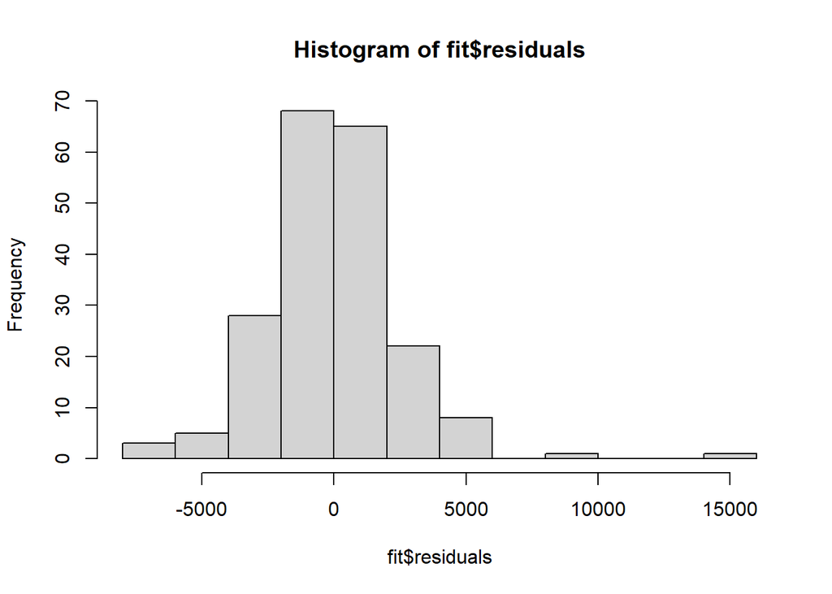

```r
hist(fit$residuals)
```

```r
shapiro.test(fit$residuals)
```

```
##
##  Shapiro-Wilk normality test
##
## data:  fit$residuals
## W = 0.92949, p-value = 2.887e-08
```

Stepwise para seleção automática de preditores

```r
fit <- step(fit)
```

```
## Start:  AIC=3203.3
## Preco ~ Comprimento + Largura + Altura + Peso + Tamanho_Motor +
##     Milhas_por_Litro_na_Cidade + Milhas_por_Litro_na_Estrada +
##     Tipo_Combustivel + Possui_Turbo + Numero_de_Portas + Estilo_do_Corpo +
##     Tracao + Localizacao_do_Motor + Numero_de_Cilindros
##
##                               Df Sum of Sq        RSS    AIC
## - Numero_de_Portas             2   6658984 1314109416 3200.3
## - Comprimento                  1       109 1307450542 3201.3
## - Peso                         1   6658513 1314108946 3202.3
## - Tipo_Combustivel             1   9729548 1317179981 3202.8
## <none>                                     1307450433 3203.3
## - Milhas_por_Litro_na_Cidade   1  16482521 1323932954 3203.8
## - Milhas_por_Litro_na_Estrada  1  22185701 1329636134 3204.7
## - Altura                       1  27903963 1335354396 3205.5
## - Largura                      1  42943022 1350393455 3207.8
## - Possui_Turbo                 1  44526091 1351976524 3208.0
## - Tracao                       2  74985314 1382435746 3210.5
## - Estilo_do_Corpo              4 125599590 1433050023 3213.7
## - Tamanho_Motor                1 130090505 1437540937 3220.4
## - Numero_de_Cilindros          6 327904494 1635354927 3236.3
## - Localizacao_do_Motor         1 315111240 1622561673 3244.7
##
## Step:  AIC=3200.32
## Preco ~ Comprimento + Largura + Altura + Peso + Tamanho_Motor +
##     Milhas_por_Litro_na_Cidade + Milhas_por_Litro_na_Estrada +
##     Tipo_Combustivel + Possui_Turbo + Estilo_do_Corpo + Tracao +
##     Localizacao_do_Motor + Numero_de_Cilindros
##
##                               Df Sum of Sq        RSS    AIC
## - Comprimento                  1      7874 1314117291 3198.3
## - Peso                         1   4914201 1319023618 3199.1
## - Tipo_Combustivel             1   9247418 1323356834 3199.7
## <none>                                     1314109416 3200.3
## - Milhas_por_Litro_na_Cidade   1  16340899 1330450316 3200.8
## - Milhas_por_Litro_na_Estrada  1  20921118 1335030534 3201.5
## - Altura                       1  27151659 1341261075 3202.4
## - Largura                      1  41535255 1355644671 3204.6
## - Possui_Turbo                 1  46324952 1360434368 3205.3
## - Tracao                       2  89170883 1403280300 3209.5
```

[output cut: 46 more lines]

```
##     Milhas_por_Litro_na_Estrada + Possui_Turbo + Estilo_do_Corpo +
##     Tracao + Localizacao_do_Motor + Numero_de_Cilindros
##
##                               Df Sum of Sq        RSS    AIC
## <none>                                     1325498655 3196.1
## - Milhas_por_Litro_na_Estrada  1  18673326 1344171981 3196.9
## - Milhas_por_Litro_na_Cidade   1  29101324 1354599979 3198.4
## - Altura                       1  32557350 1358056005 3198.9
## - Possui_Turbo                 1  56321256 1381819912 3202.4
## - Estilo_do_Corpo              4 113404603 1438903259 3204.6
## - Largura                      1  82586583 1408085239 3206.2
## - Tracao                       2 125636288 1451134943 3210.3
## - Numero_de_Cilindros          6 342046270 1667544925 3230.2
## - Tamanho_Motor                1 264073470 1589572126 3230.6
## - Localizacao_do_Motor         1 306352819 1631851475 3235.8
```

```r
summary(fit)
```

```
##
## Call:
## lm(formula = Preco ~ Largura + Altura + Tamanho_Motor + Milhas_por_Litro_na_Cidade +
##     Milhas_por_Litro_na_Estrada + Possui_Turbo + Estilo_do_Corpo +
##     Tracao + Localizacao_do_Motor + Numero_de_Cilindros, data = dados)
##
## Residuals:
##    Min     1Q Median     3Q    Max
##  -6562  -1418    -72   1318  15821
##
## Coefficients:
##                              Estimate Std. Error t value Pr(>|t|)
## (Intercept)                 -44615.95   12560.82  -3.552 0.000487 ***
## Largura                        673.91     200.68   3.358 0.000956 ***
## Altura                         244.04     115.74   2.109 0.036364 *
## Tamanho_Motor                   85.18      14.18   6.005 1.02e-08 ***
## Milhas_por_Litro_na_Cidade    -295.53     148.25  -1.993 0.047714 *
## Milhas_por_Litro_na_Estrada    240.27     150.47   1.597 0.112047
## Possui_Turboturbo             1634.18     589.27   2.773 0.006132 **
## Estilo_do_Corpohardtop       -4011.30    1503.63  -2.668 0.008329 **
## Estilo_do_Corpohatchback     -3236.23    1291.72  -2.505 0.013115 *
## Estilo_do_Corposedan         -2315.99    1309.58  -1.768 0.078662 .
## Estilo_do_Corpowagon         -3838.11    1470.38  -2.610 0.009805 **
## Tracaofwd                     -929.31    1093.87  -0.850 0.396690
## Tracaorwd                     1473.18    1157.50   1.273 0.204746
## Localizacao_do_Motorrear     12711.44    1965.32   6.468 8.99e-10 ***
## Numero_de_Cilindrosfive      -5085.86    2166.72  -2.347 0.019993 *
## Numero_de_Cilindrosfour      -8947.77    2231.81  -4.009 8.90e-05 ***
## Numero_de_Cilindrossix       -6270.93    1893.99  -3.311 0.001122 **
## Numero_de_Cilindrosthree     -3728.22    3824.54  -0.975 0.330953
## Numero_de_Cilindrostwelve    -5795.66    3326.82  -1.742 0.083190 .
## Numero_de_Cilindrostwo       -3733.33    3184.68  -1.172 0.242625
## ---
## Signif. codes:  0 '***' 0.001 '**' 0.01 '*' 0.05 '.' 0.1 ' ' 1
##
## Residual standard error: 2706 on 181 degrees of freedom
## Multiple R-squared:  0.8951, Adjusted R-squared:  0.884
## F-statistic: 81.25 on 19 and 181 DF,  p-value: < 2.2e-16
```